# IPL - Exploratory Data Analysis | Data Science | Python | AI

### 4.19 Who is Most Trusted Umpires in IPL

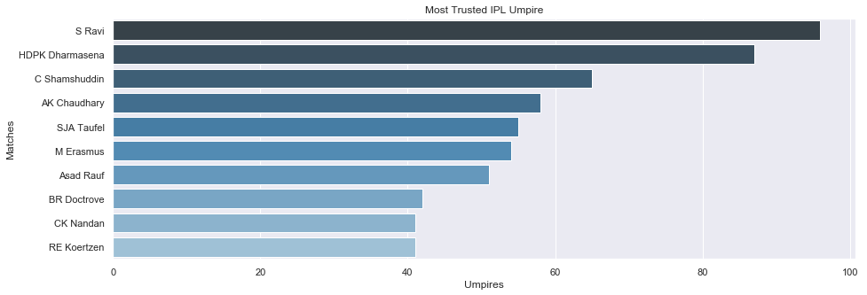

```python
New_Data1 = IPL.loc[:, ['umpire1', 'umpire2']]
umpire1 = New_Data1['umpire1'].tolist()
umpire2 = New_Data1['umpire2'].tolist()
umpires = umpire1 + umpire2
from collections import Counter
c = Counter(umpires)
umpires = []
count = []
for i,j in c.most_common(10):
    umpires.append(i)
    count.append(j)


plt.gcf().set_size_inches(15,5)
plt.xlabel('Umpires')
plt.ylabel('Matches')
plt.title('Most Trusted IPL Umpire')
#plt.bar(umpires, count, color = 'mint' )
sns.barplot(count,umpires, palette="Blues_d")

plt.show()
```

**S Ravi is most trusted IPL umpires followed by Dharamsena & Shashuddin**

### 4.19 Which Venue did Weather Affected Most**

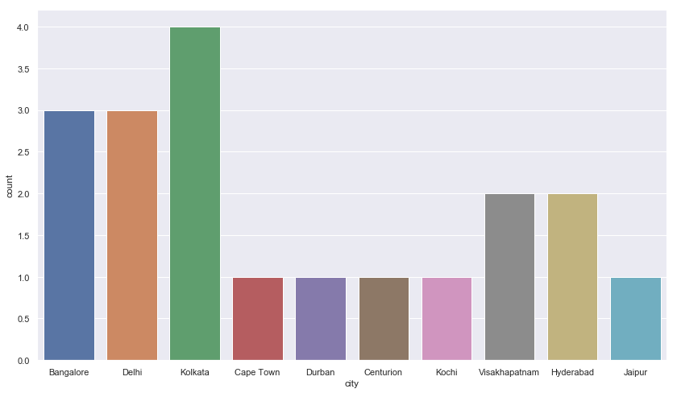

```python
sns.countplot(IPL.city[IPL.dl_applied==1])
```

**Kolkata has been unfortunate stadium where weather may have affected most. As IPL is played in April-May, weather gods are away and most matches have been unaffected**

### 4.21 Best Stadium to Chase and Win**

```python
IPL.venue[IPL.win_by_wickets!=0].mode()
```

```
0    Eden Gardens
dtype: object
```

### 4.20 Best Chasing Venues**

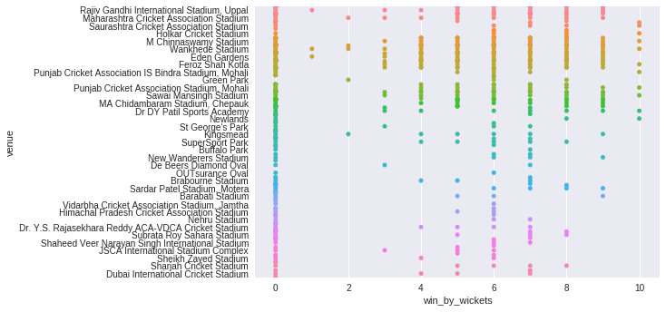

```python
sns.swarmplot(x='win_by_wickets', y='venue',data=IPL)
plt.show()
```

### 4.22 Best Team In Best Chasing Venue

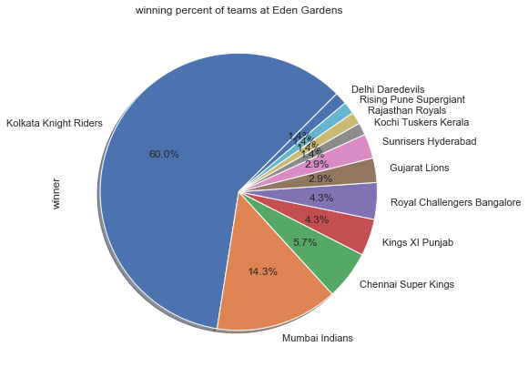

```python
#Winning Percent of teams at Eden Gardens
#BT_def1 = IPL[IPL.venue=='Eden Gardens']['winner']
#BT_def1.value_counts()

#BT_def1 = IPL[IPL.venue=='Eden Gardens']['winner'].value_counts(normalize=True)*100
#BT_def1.plot(kind = 'bar' , title='winning percent at Eden Gardens' , figsize = (7,7) , grid=True).legend(bbox_to_anchor=(1.2, 0.5))

df = IPL[IPL.venue=='Eden Gardens']['winner'].value_counts(normalize=True)*100
df.plot(kind = 'pie' , title = 'winning percent of teams at Eden Gardens' ,
        figsize = (7,7) , startangle=45, shadow='True', autopct='%.1f%%', grid = True)
```

**The Best Team is Kolkata Knight Riders at Eden Gardens, which is best Chasing Stadium. This also signals that Home team has clear advantage in home turf**

### 4.23 Best Stadium to Bat first and Win**

```python
IPL.venue[IPL.win_by_runs!=1].mode()
```

```
0    M Chinnaswamy Stadium
dtype: object
```

## 4.23 Best Defending Venue**

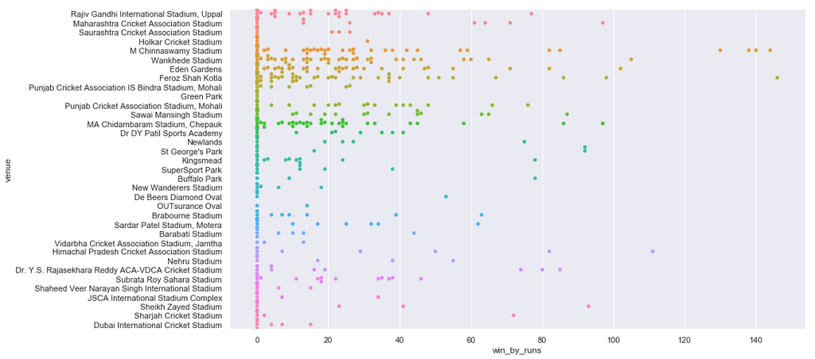

```python
sns.swarmplot(x='win_by_runs', y='venue', data=IPL)
plt.show()
```

**Best Defending Venue is Chinnaswamy Stadium Bangalore.**

### 4.24 Best Team In Best Defending Venue

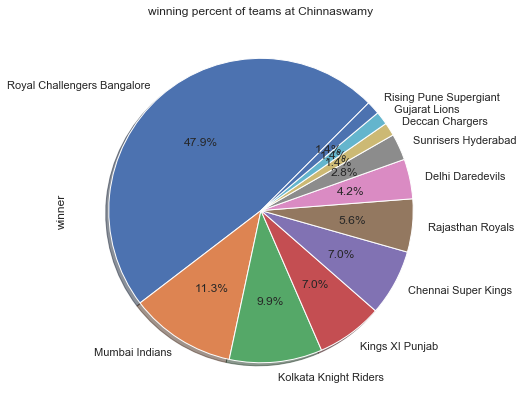

```python
#Winning Percent of teams at Chinnaswamy Stadium
#BT_def1 = IPL[IPL.venue=='M Chinnaswamy Stadium']['winner']
#BT_def1.value_counts()

#BT_def1 = IPL[IPL.venue=='M Chinnaswamy Stadium']['winner'].value_counts(normalize=True)*100
#BT_def1.plot(kind = 'bar' , title='winning percent at Chinnaswamy' , figsize = (7,7) , grid=True).legend(bbox_to_anchor=(1.2, 0.5))

df = IPL[IPL.venue=='M Chinnaswamy Stadium']['winner'].value_counts(normalize=True)*100
df.plot(kind = 'pie' , title = 'winning percent of teams at Chinnaswamy' ,
        figsize = (7,7) , startangle=45, shadow='True', autopct='%.1f%%', grid = True)
```

**The Best Team is Royal Challengers Bangalore in Chinnaswamy Stadium, which is best defending Stadium. This also again reconfirms that Home team has clear advantage in home turf**

### 4.25 Which Team is Best in Defending**

```python
IPL.winner[IPL.win_by_runs!=1].mode()
```

```
0    Mumbai Indians
dtype: object
```

### 4.25 MOSt Win by Batting first and Defending Total

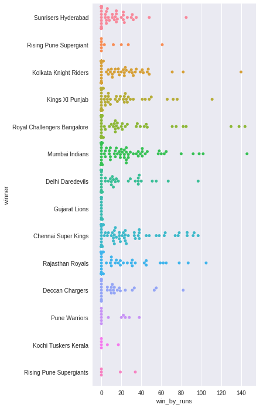

```python
plt.figure(figsize=(5,12))
sns.swarmplot(x='win_by_runs',y='winner',data=IPL)
plt.show()
```

**Mumbai Indian is Top Team in defending, followed by CSK**

### 4.15 Which Team is Best in Chasing**

```python
IPL.winner[IPL.win_by_wickets!=0].mode()
```

```
0    Kolkata Knight Riders
dtype: object
```

### 4.25 MOSt Win by Bowling first and Fielding First Winner**

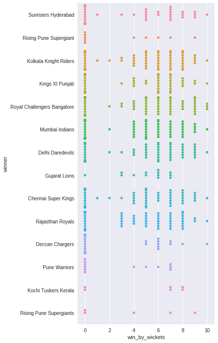

```python
plt.figure(figsize=(5,12))
sns.swarmplot(x='win_by_wickets',y='winner',data=IPL)
plt.show()
```

**CSK & KKR seems to be great chasers**

### 4.27 Home Turf Advantage - Team wins in home city vs other cities¶

**Each team plays two matches against the other teams, one in its home city and other in the home city of the opposite team. It would be interesting see if playing in home city increases a teams chances of a win.**

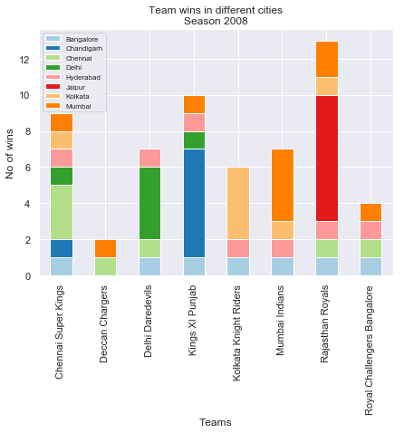

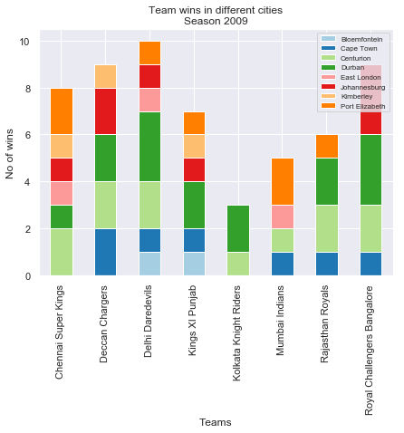

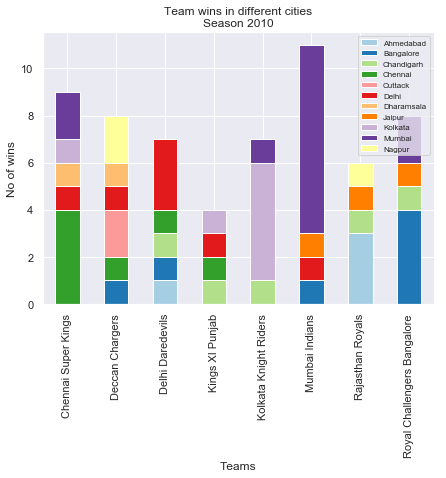

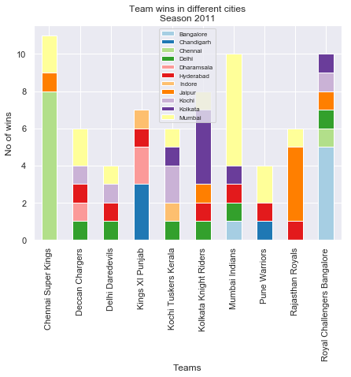

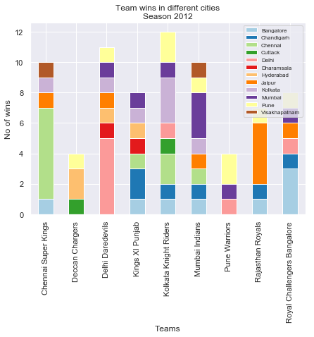

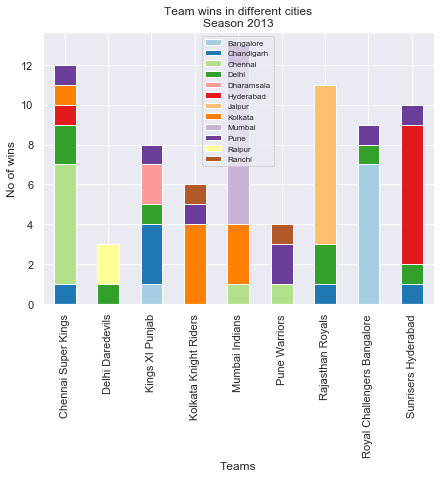

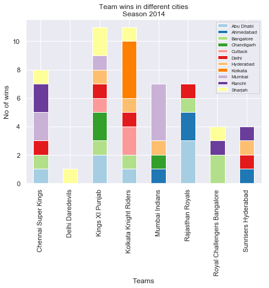

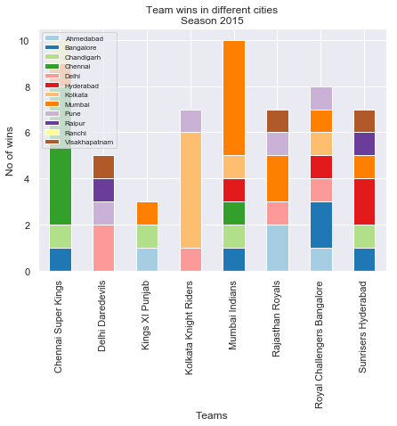

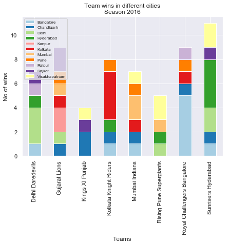

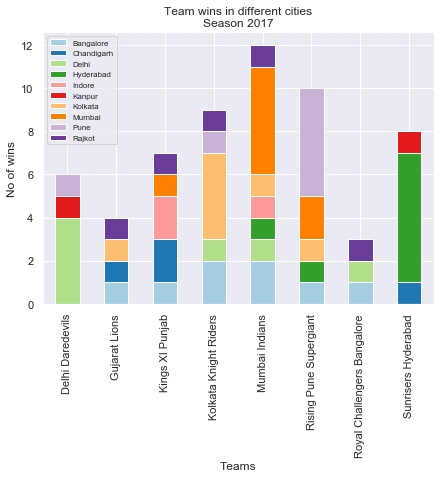

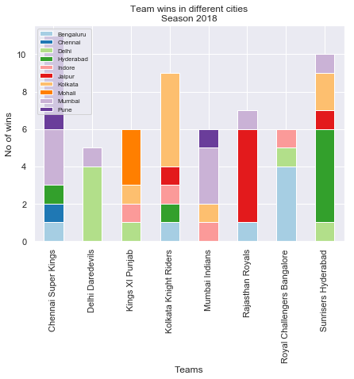

```python
#No of wins by team and season in each city
x, y = 2008, 2019
while x < y:
    wins_percity = IPL[IPL['season'] == x].groupby(['winner', 'city'])['id'].count().unstack()
    plot = wins_percity.plot(kind='bar', stacked=True, title="Team wins in different cities\nSeason "+str(x), figsize=(7, 5))
    sns.set_palette("Paired", len(IPL['city'].unique()))
    plot.set_xlabel("Teams")
    plot.set_ylabel("No of wins")
    plot.legend(loc='best', prop={'size':8})
    x+=1
```

**Overall, only few Team gets advantage of home matches, but many of them turn to be IPL Champions. in 2018, Rajasthan Royal, Kolkata Knight Riders and Sunrisers Hyderabad are Top team in Home matches.**

## 5. Conclulsion

**We have completed detailed analysis, but there is still scope further deep analysis. We have observed following relevent conclusions.**

```
- Mumbai is Popular Destination of IPL
- Favourite Ground is Chinnaswamy Stadium Bangalore
- The 2 Most successful Teams in IPL History are - Mumbai Indians & Chennai Super Kings.
- Chennai Super Kings is Most Consistent Team
- Chris Gayle, Rohit Sharma & AB De Villers are Icons of IPLs
- Rashid Khan is most Likely is emerging Icon
- Toss Winning Matters. 51.3% Matches Won out of 696 by Toss Winner
- Match Winners post winning the Toss, chose to Field First over Bat
- KKR, Mumbai Indian, RCB & KingsXIPunjab Prefers to field first
- S Ravi, Dharmasena & Shamshuddin have been entrusted with  Crucial Decision Taking role multiple time.
- Kolkata most affected by weather, though numbers are insignificant.
- Eden Garden has emerged as Best Chasing Venue in IPL History
- Chinnaswamy Stadium of Bangalore has helped several Team in defending the Total Scored
- It was proven that home turf gives advantage to home team, as RCB has won maximum in Bangalore Chinnaswamy Stadium
- Mumbai Indians is Best Defender of Total in IPL, Followed by CSK
- Kolkata Knight Rider is Best Chaser of Total in IPL.
- Many Team got home turf advantage, out of them later on turned to be IPL champon later. These team got advantage -         2008 – RR & KingsXI  / 2010 – MI, KKR, CSK / 2011 – CSK/ 2012 – CSK / 2013 – CSK, RR, SRH / 2014 – CSK/ 2015 – MI,         KKR / 2016 – RCB / 2017 – Mumbai Indian / 2018 – SRH, RR, KKR
```